# useR! 2024 Report

This report summarizes attendee demographics and feedback from the 2024 useR! conference, held July 8–11 in Salzburg, Austria.

Author

Dillon Sparks

## Overview

241 in-person/hybrid participants and 6 virtual participants responded to the survey.

## Demographics of Participants

### Age

(Q: How old are you?)

**Age barplot**

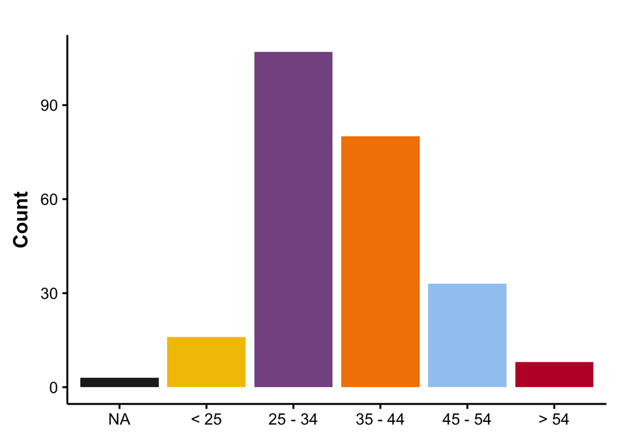

**Age data table**

| Age | n | % |
| --- | --- | --- |
| NA | 3 | 1 |
| < 25 | 16 | 6 |
| 25 - 34 | 107 | 43 |
| 35 - 44 | 80 | 32 |
| 45 - 54 | 33 | 13 |
| > 54 | 8 | 3 |

### Country of origin

(Q: What is your country of origin?)

Counts < 3 are replaced with 1.5 to preserve anonymity, with the NA count adjusted to maintain the total count.

**Map**

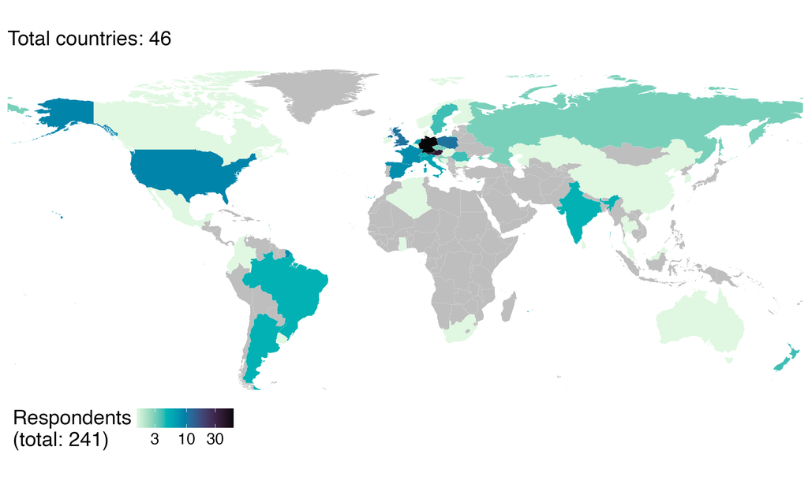

**Data**

| Origin | iso3c | n |
| --- | --- | --- |
| Algeria | DZA | 1.5 |
| Argentina | ARG | 5.0 |
| Australia | AUS | 1.5 |
| Austria | AUT | 39.0 |
| Belgium | BEL | 1.5 |
| Bosnia & Herzegovina | BIH | 1.5 |
| Brazil | BRA | 5.0 |
| Bulgaria | BGR | 1.5 |
| Canada | CAN | 1.5 |
| China | CHN | 1.5 |
| Colombia | COL | 1.5 |
| Croatia | HRV | 3.0 |
| Cyprus | CYP | 3.0 |
| Czechia | CZE | 3.0 |
| Denmark | DNK | 1.5 |
| Ecuador | ECU | 1.5 |
| Finland | FIN | 1.5 |
| France | FRA | 8.0 |
| Germany | DEU | 60.0 |
| Ghana | GHA | 1.5 |
| Hong Kong SAR China | HKG | 1.5 |
| Hungary | HUN | 1.5 |
| India | IND | 5.0 |
| Ireland | IRL | 1.5 |
| Italy | ITA | 6.0 |
| Kazakhstan | KAZ | 1.5 |
| Malaysia | MYS | 1.5 |
| Mexico | MEX | 1.5 |
| Netherlands | NLD | 6.0 |
| New Zealand | NZL | 4.0 |
| Norway | NOR | 1.5 |
| Poland | POL | 11.0 |
| Romania | ROU | 4.0 |
| Russia | RUS | 3.0 |
| Singapore | SGP | 1.5 |
| Slovakia | SVK | 1.5 |
| South Africa | ZAF | 1.5 |
| South Korea | KOR | 1.5 |
| Spain | ESP | 8.0 |
| Sri Lanka | LKA | 1.5 |
| Sweden | SWE | 4.0 |
| Switzerland | CHE | 5.0 |
| Thailand | THA | 1.5 |
| United Kingdom | GBR | 11.0 |
| United States | USA | 9.0 |
| Uruguay | URY | 1.5 |
| NA | NA | 6.0 |

| Continent of origin | n | % |
| --- | --- | --- |
| Africa | 3 | 1 |
| Asia | 18 | 7 |
| Europe | 185 | 76 |
| North America | 12 | 5 |
| Oceania | 5 | 2 |
| South America | 15 | 6 |
| NA | 9 | 4 |

### Country of residence

(Q: In what country do you currently reside?)

Counts < 3 are replaced with 1.5 to preserve anonymity, with the NA count adjusted to maintain the total count.

**Map**

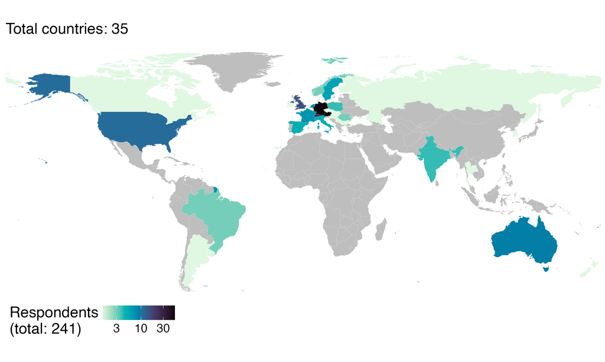

**Data**

| Residence | iso3c | n |
| --- | --- | --- |
| Argentina | ARG | 1.5 |
| Australia | AUS | 9.0 |
| Austria | AUT | 53.0 |
| Belgium | BEL | 1.5 |
| Brazil | BRA | 3.0 |
| Bulgaria | BGR | 1.5 |
| Canada | CAN | 1.5 |
| Croatia | HRV | 1.5 |
| Cyprus | CYP | 3.0 |
| Czechia | CZE | 1.5 |
| Denmark | DNK | 1.5 |
| Finland | FIN | 1.5 |
| France | FRA | 7.0 |
| Germany | DEU | 52.0 |
| Hungary | HUN | 1.5 |
| India | IND | 4.0 |
| Ireland | IRL | 1.5 |
| Italy | ITA | 5.0 |
| Netherlands | NLD | 8.0 |
| New Zealand | NZL | 1.5 |
| Norway | NOR | 3.0 |
| Poland | POL | 4.0 |
| Romania | ROU | 3.0 |
| Russia | RUS | 1.5 |
| Serbia | SRB | 1.5 |
| Singapore | SGP | 1.5 |
| Slovakia | SVK | 1.5 |
| South Korea | KOR | 1.5 |
| Spain | ESP | 5.0 |
| Sweden | SWE | 6.0 |
| Switzerland | CHE | 23.0 |
| Thailand | THA | 1.5 |
| United Kingdom | GBR | 15.0 |
| United States | USA | 11.0 |
| Uruguay | URY | 1.5 |
| NA | NA | 6.0 |

| Continent of residence | n | % |
| --- | --- | --- |
| Asia | 12 | 5 |
| Europe | 201 | 83 |
| North America | 12 | 5 |
| Oceania | 11 | 5 |
| South America | 6 | 2 |
| NA | 5 | 2 |

### Racial/ethnic identity

(Q: What racial/ethnic group(s) do you identify with?)

Respondents could select multiple options.

**Bar plot**

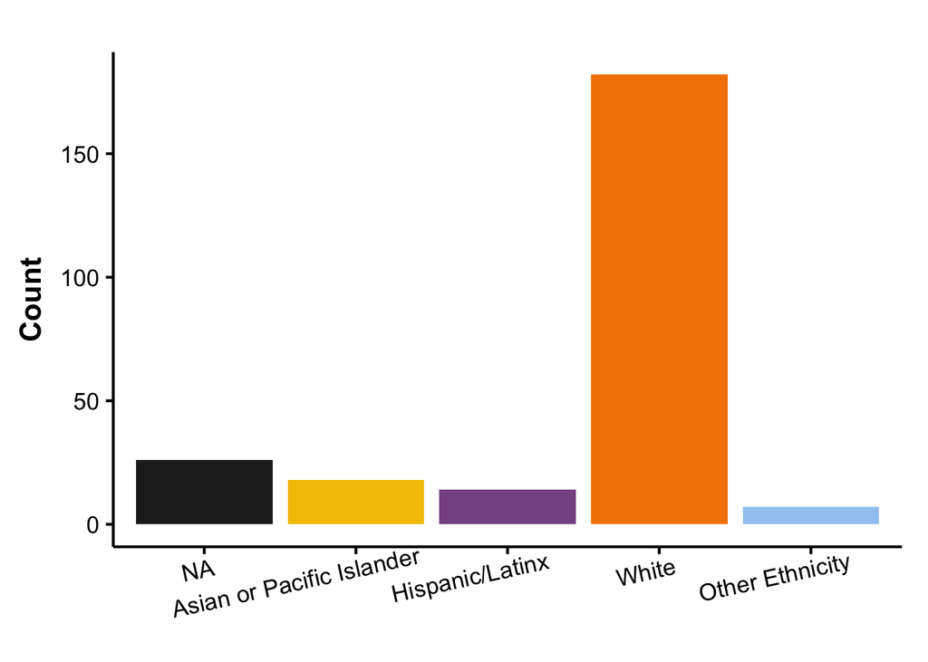

**Data**

| Ethnicity | n | % |
| --- | --- | --- |
| NA | 26 | 11 |
| Asian or Pacific Islander | 18 | 7 |
| Hispanic/Latinx | 14 | 6 |
| White | 182 | 74 |
| Other Ethnicity | 7 | 3 |

The following ethnic categories were represented in the “Other Ethnicity” count: Black/African/Caribbean, Middle-Eastern/North-African, Mixed/Multiple ethnic groups.

### Gender

(Q: What is your gender?)

**Bar plot**

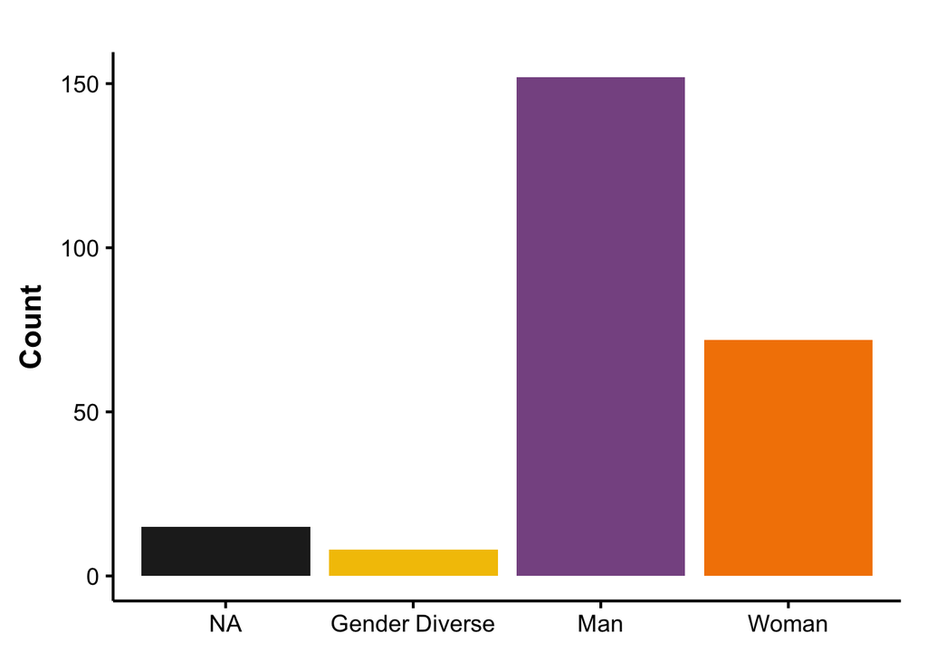

**Data**

| barplot_gender | n | % |
| --- | --- | --- |
| NA | 15 | 6 |
| Gender Diverse | 8 | 3 |
| Man | 152 | 62 |
| Woman | 72 | 29 |

### Disability

(Q: Do you have any disabilities or impairments that affect the way you work/study or place special requirements on your working/learning environment?)

**6% of respondents (n = 14)** declared a disability or impairment that affects the way they work or study.

(Q: What kind of disability do you have?)

The following disabilities were represented among useR! 2024 participants:

- A vision impairment
- A hearing impairment
- A mobility impairment
- A learning disability
- A mental health disorder
- Other disability

Participants specified the following under “Other disability”: dysautonomia, autism & ADHD .

### LGBTQIA+ identity

(Q: Do you identify as LGBTQIA+?)

**9% of respondents (n = 23)** identified as lesbian, gay, bisexual, transgender, queer, intersex, or another sexual or gender minority.

## Education & Life situation

### Education level

(Q: What is the highest level of education you have completed?)

**Bar plot**

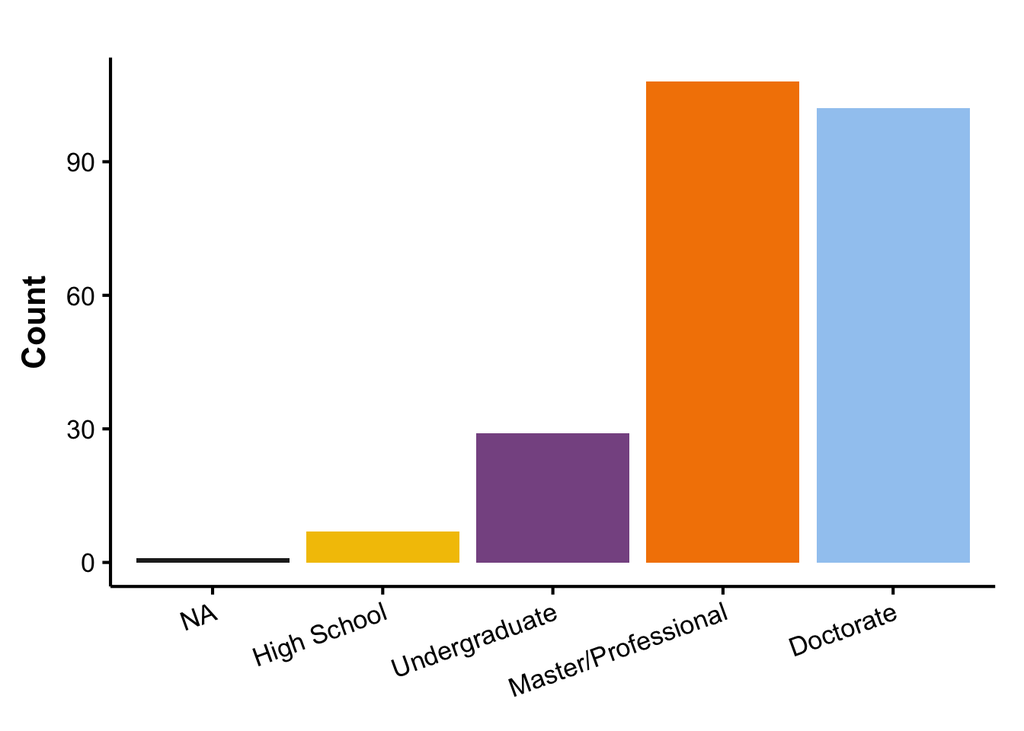

**Data**

| Education | n | % |
| --- | --- | --- |
| NA | 1 | 0 |
| High School | 7 | 3 |
| Undergraduate | 29 | 12 |
| Master/Professional | 108 | 44 |
| Doctorate | 102 | 41 |

(Q: Are you currently a student?)

**23% of respondents (n = 56)** declared they were currently students, **38% (n = 21) of these students** were part-time.

### Employment status

(Q: What is your current employment status?)

**Bar plot**

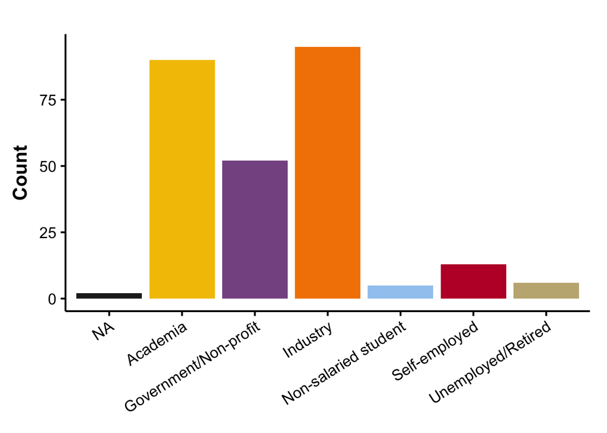

**Data**

| Employment | n | % |
| --- | --- | --- |
| NA | 2 | 1 |
| Academia | 90 | 34 |
| Government/Non-profit | 52 | 20 |
| Industry | 95 | 36 |
| Non-salaried student | 5 | 2 |
| Self-employed | 13 | 5 |
| Unemployed/Retired | 6 | 2 |

(Q: If in paid employment, are you:)

**95% of respondents (n = 234)** declared they had paid employment, **14% (n = 32) of these respondents** only had part-time paid work.

### Caregiving status

(Q: Do you have any children or adults that depend on you for day-to-day care?)

**31% of respondents (n = 77)** have children or adults that depend on them for day-to-day care.

## Interest in R

### R Users

(Q: What is your interest in useR!?)

**95% of respondents (n = 234)** said that they use R.

#### Length of experience

(Q: How long have you been using R for?)

**Bar plot**

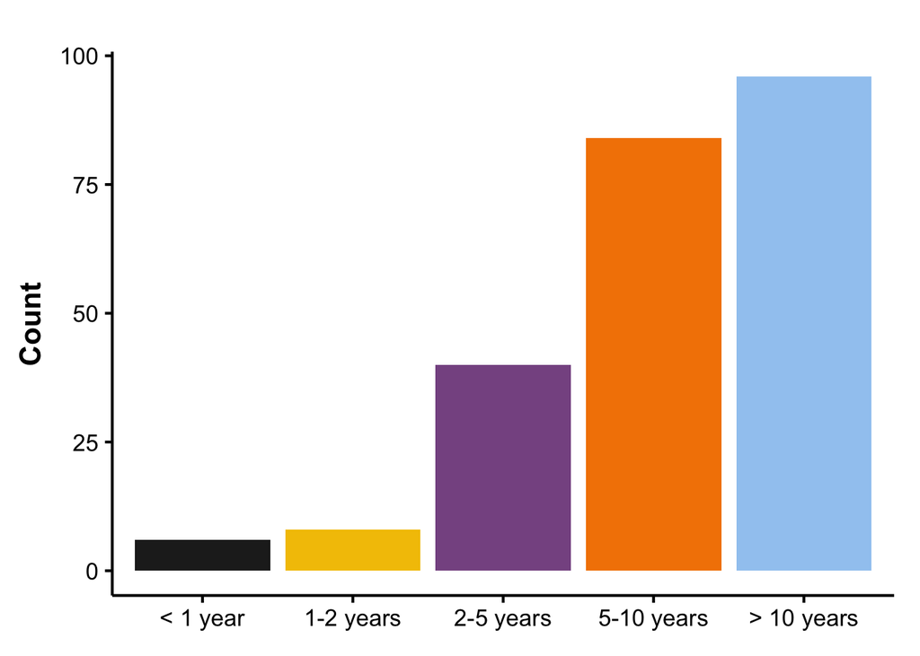

**Data**

| Experience | n | % |
| --- | --- | --- |
| < 1 year | 6 | 3 |
| 1-2 years | 8 | 3 |
| 2-5 years | 40 | 17 |
| 5-10 years | 84 | 36 |
| > 10 years | 96 | 41 |

### Non R Users

**3% of respondents (n = 8)** said that they are interested in starting to use R.

## Involvement in useR!

(Q: Was this your first useR!?)

**68% (n = 169)** said they were attending useR! for the first time

### Sessions attended

(Q: What type of sessions did you attend?)

**Upset plot**

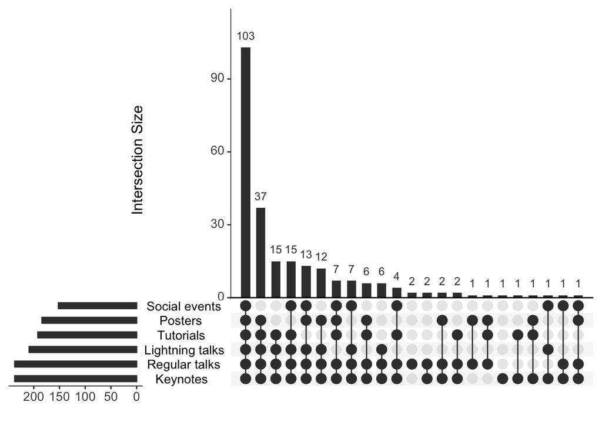

**Session totals**

| Attendance | n | % |
| --- | --- | --- |
| Keynotes (K) | 237 | 98 |
| Regular talks (R) | 237 | 98 |
| Lightning talks (L) | 209 | 87 |
| Tutorials (T) | 192 | 80 |
| Posters (P) | 184 | 76 |
| Social events (S) | 152 | 63 |

**Intersection size**

| Sessions | n |
| --- | --- |
| K-R-L-P-T-S | 103 |
| K-R-L-P-T | 37 |
| K-R-L-T | 15 |
| K-R-L-T-S | 15 |
| K-R-L-P-S | 13 |
| K-R-L-P | 12 |
| K-R-L-S | 7 |
| K-R-P-T-S | 7 |
| None | 6 |
| K-R-L | 6 |
| K-R-P-T | 6 |
| K-R-T-S | 4 |
| K-R | 2 |
| K-R-P | 2 |
| K-R-T | 2 |
| R | 2 |
| K | 1 |
| K-L-S | 1 |
| K-P-T | 1 |
| K-R-P-S | 1 |
| K-R-S | 1 |
| K-T | 1 |
| R-P | 1 |
| R-P-T | 1 |

### Financial support

(Q: Were you offered financial support to attend the in-person conference?

Counts < 5 are replaced with 2.5 to preserve anonymity, with the NA count adjusted to maintain the total count.

**Bar plot**

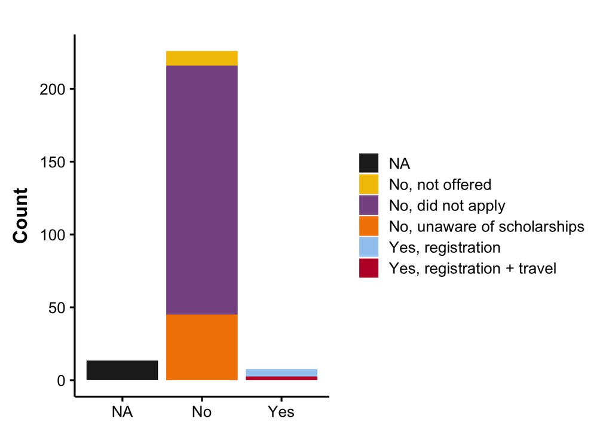

**Data**

| support | n | % |
| --- | --- | --- |
| No, not offered | 10.0 | 4 |
| No, did not apply | 171.0 | 69 |
| No, unaware of scholarships | 45.0 | 18 |
| Yes, registration | 5.0 | 2 |
| Yes, registration + travel | 2.5 | 1 |
| NA | 13.5 | 5 |

## Satisfaction with useR!

Q: How satisfied were you with the following aspects of the useR! program?

### Events

**Bar plot**

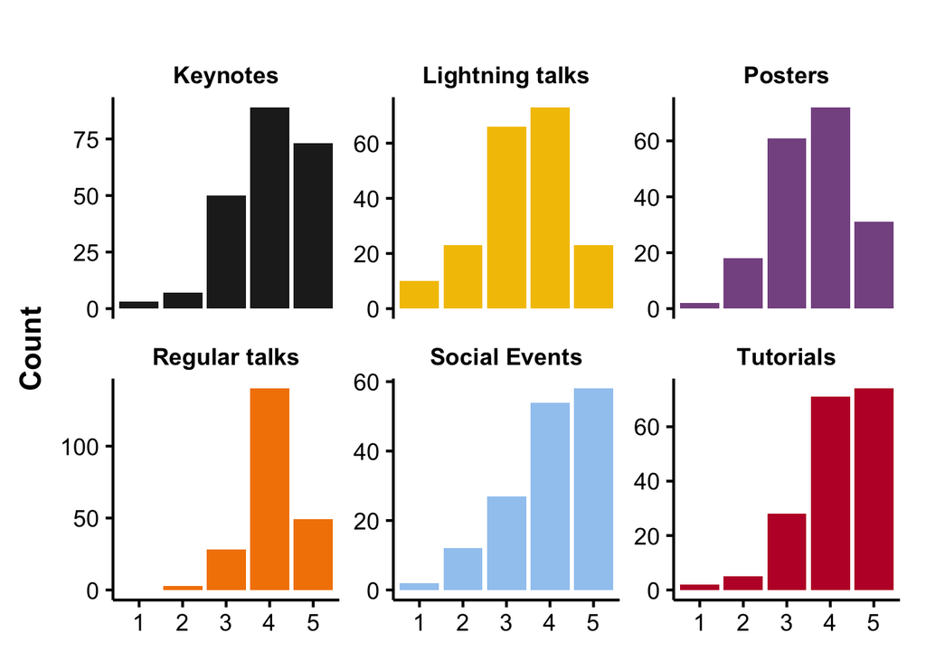

**Data**

| Session Type | Score | n | % |
| --- | --- | --- | --- |
| Keynotes | 1 | 3 | 1 |
| Keynotes | 2 | 7 | 3 |
| Keynotes | 3 | 50 | 23 |
| Keynotes | 4 | 89 | 40 |
| Keynotes | 5 | 73 | 33 |
| Lightning talks | 1 | 10 | 5 |
| Lightning talks | 2 | 23 | 12 |
| Lightning talks | 3 | 66 | 34 |
| Lightning talks | 4 | 73 | 37 |
| Lightning talks | 5 | 23 | 12 |
| Posters | 1 | 2 | 1 |
| Posters | 2 | 18 | 10 |
| Posters | 3 | 61 | 33 |
| Posters | 4 | 72 | 39 |
| Posters | 5 | 31 | 17 |
| Regular talks | 2 | 3 | 1 |
| Regular talks | 3 | 28 | 13 |
| Regular talks | 4 | 140 | 64 |
| Regular talks | 5 | 49 | 22 |
| Social Events | 1 | 2 | 1 |
| Social Events | 2 | 12 | 8 |
| Social Events | 3 | 27 | 18 |
| Social Events | 4 | 54 | 35 |
| Social Events | 5 | 58 | 38 |
| Tutorials | 1 | 2 | 1 |
| Tutorials | 2 | 5 | 3 |
| Tutorials | 3 | 28 | 16 |
| Tutorials | 4 | 71 | 39 |
| Tutorials | 5 | 74 | 41 |

### Accessibility practices

(Q: How would you rate the accessibility practices this year?)

**Bar plot**

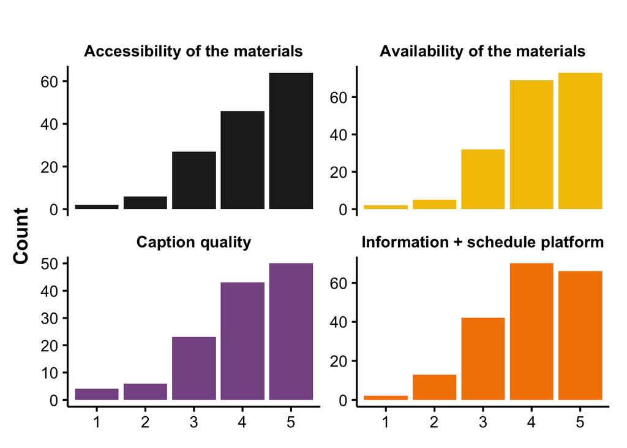

**Data**

| Accessibility Type | Score | n | % |
| --- | --- | --- | --- |
| Accessibility of the materials | 1 | 2 | 1 |
| Accessibility of the materials | 2 | 6 | 4 |
| Accessibility of the materials | 3 | 27 | 19 |
| Accessibility of the materials | 4 | 46 | 32 |
| Accessibility of the materials | 5 | 64 | 44 |
| Availability of the materials | 1 | 2 | 1 |
| Availability of the materials | 2 | 5 | 3 |
| Availability of the materials | 3 | 32 | 18 |
| Availability of the materials | 4 | 69 | 38 |
| Availability of the materials | 5 | 73 | 40 |
| Caption quality | 1 | 4 | 3 |
| Caption quality | 2 | 6 | 5 |
| Caption quality | 3 | 23 | 18 |
| Caption quality | 4 | 43 | 34 |
| Caption quality | 5 | 50 | 40 |
| Information + schedule platform | 1 | 2 | 1 |
| Information + schedule platform | 2 | 13 | 7 |
| Information + schedule platform | 3 | 42 | 22 |
| Information + schedule platform | 4 | 70 | 36 |
| Information + schedule platform | 5 | 66 | 34 |

### General organization

(Q: How satisfied were you with the following aspects of the useR! organization?)

**Bar plot**

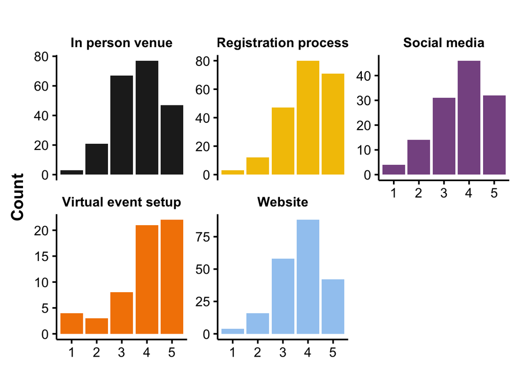

**Data**

| Organization Type | Score | n | % |
| --- | --- | --- | --- |
| In person venue | 1 | 3 | 1 |
| In person venue | 2 | 21 | 10 |
| In person venue | 3 | 67 | 31 |
| In person venue | 4 | 77 | 36 |
| In person venue | 5 | 47 | 22 |
| Registration process | 1 | 3 | 1 |
| Registration process | 2 | 12 | 6 |
| Registration process | 3 | 47 | 22 |
| Registration process | 4 | 80 | 38 |
| Registration process | 5 | 71 | 33 |
| Social media | 1 | 4 | 3 |
| Social media | 2 | 14 | 11 |
| Social media | 3 | 31 | 24 |
| Social media | 4 | 46 | 36 |
| Social media | 5 | 32 | 25 |
| Virtual event setup | 1 | 4 | 7 |
| Virtual event setup | 2 | 3 | 5 |
| Virtual event setup | 3 | 8 | 14 |
| Virtual event setup | 4 | 21 | 36 |
| Virtual event setup | 5 | 22 | 38 |
| Website | 1 | 4 | 2 |
| Website | 2 | 16 | 8 |
| Website | 3 | 58 | 28 |
| Website | 4 | 88 | 42 |
| Website | 5 | 42 | 20 |

### Would you attend a future useR!?

(Q: Will you attend a future useR!?)

#### Online

(Q: Would you attend a future online useR! conference?)

**Barplot**

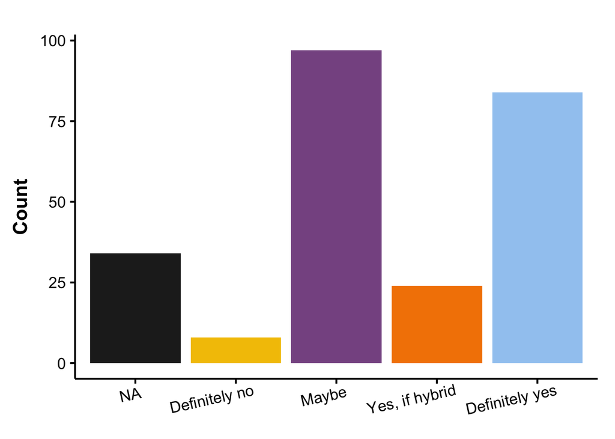

**Data**

| futureOnline | n | % |
| --- | --- | --- |
| NA | 34 | 14 |
| Definitely no | 8 | 3 |
| Maybe | 97 | 39 |
| Yes, if hybrid | 24 | 10 |
| Definitely yes | 84 | 34 |

#### In-person

(Q: Would you attend a future in-person useR! conference?)

Counts < 5 are replaced with 2.5 to preserve anonymity, with the NA count adjusted to maintain the total count.

**Barplot**

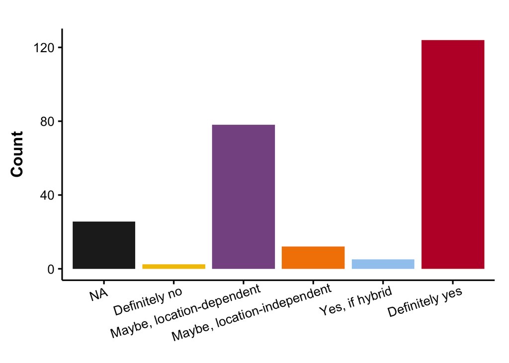

**Data**

| futureInPerson | n | % |
| --- | --- | --- |
| Definitely no | 2.5 | 1 |
| Maybe, location-dependent | 78.0 | 32 |
| Maybe, location-independent | 12.0 | 5 |
| Yes, if hybrid | 5.0 | 2 |
| Definitely yes | 124.0 | 50 |
| NA | 25.5 | 10 |

## General comments

Q: Do you have other comments on the useR! conference series?

|  | Comment |
| --- | --- |
| 1 | Depends on location: I would, if it is in Europe ( I am from europe) |
| 2 | Excited to see the conference revive after Covid. Will this turn into a biannual event? |
| 3 | Have more social events that ease networking. Maybe several events in parallel, so they will be less crowded? |
| 4 | Having a board full of statisticians and pharma people has led to an unbalanced schedule. How nobody saw this and thought maybe we should represent a broader swath of the R community is unacceptable. … |
| 5 | I don't think online events are good in all honesty. I've been to a few and they're extremely bland and difficult to pay attention to. That can sometimes be said about in person but at least there is … |
| 6 | I highly believe in keeping useR! in-person, with at least regional jobs to facilitate networking -- that is not really the same option online. |
| 7 | I think better theme grouping for lightning talks and better chair training. Some chairs did not keep time and this caused a lot of issues with syncing across rooms. AV was very poorly organised. Ther… |
| 8 | I think livestteaming is a good feature (e.g. Juliacon), although I can also foresee that it is not easy. |
| 9 | I think that the whole inclusivity/gender/code of conduct stuff went overboard; it was just too much. I asked myself on multiple occasions what must have happened during last conferences in order to j… |
| 10 | I think this useR was lees diverse than others. It appears that the 20-minute oral presentations are predominantly given by males. Just see the first morning in the conference... Also when females do … |

[output cut: 26 more lines]

## Feedback from non-participants

**2 people** responded to the survey to give feedback as a potential participant that did not attend the conference.

### Interest in useR! conference

“Non-participant respondents were interested in useR! due to their interest in the following areas:”

| Area of Interest | n |
| --- | --- |
| Data science | 1 |
| R (as current user) | 1 |

### Reasons for not participating

(Q: Did you participate in useR! 2024?) (Q: (Conditional on 17) Why did you not participate?)

| Reason | n |
| --- | --- |
| I did not have the time | 1 |
| I could not afford the registration fee for the in person event | 0 |
| I could not afford the travel expenses for the in person event | 0 |
| I did not have sufficient internet access for the virtual event | 0 |
| My visa application was denied for the in person event | 0 |
| The content was not interesting | 0 |
| The in person or virtual event was not accessible for me | 0 |
| NA | 1 |

### Application for financial support

(Q: Did you apply for a diversity or needs-based scholarship?)

| support | n |
| --- | --- |
| No, not offered | 0 |
| No, did not apply | 0 |
| No, unaware of scholarships | 0 |
| Yes, registration | 0 |
| Yes, registration + travel | 0 |
| NA | 2 |

### Would you attend a future useR!?

(Q: Will you attend a future useR!?)

#### Online

**50% of respondents (n = 1)** responded “Maybe” when asked if they planned to attend a future online useR!

#### In-person

**50% of respondents (n = 1)** responded “Maybe, depending on the location” when asked if they planned to attend a future in-person useR!